# 13: Application II

#### NDVI raster (black square) centered around the measurement station of CH Oerlikon, at month 02/2010

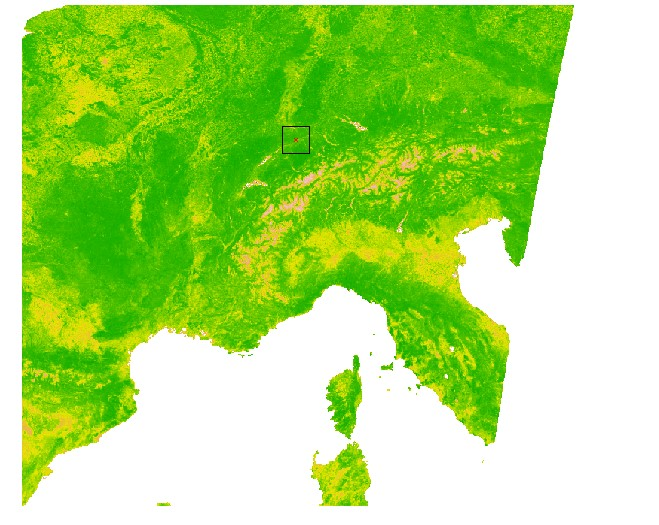

#### Loading the response variables

- Load the file containing the response variables to be interpolated, and put it in a dataframe. Print some lines of the dataframe to understand what does it contain.

```r
flux_data <- read.csv("data/flux_dataset.csv")
head(flux_data)
```

```
##   X sitename year month         y fpar_loess_per_month TA_F_per_month
## 1 1   AR-Vir 2010     2 18.155930            0.7175273       27.90639
## 2 2   AR-Vir 2010     3 16.566188            0.8062719       25.88332
## 3 3   AR-Vir 2010     4 11.883871            0.8253712       21.08527
## 4 4   AR-Vir 2010     5  7.550117            0.7912010       17.02619
## 5 5   AR-Vir 2010     9 12.171233            0.6176354       19.77360
## 6 6   AR-Vir 2010    10 12.463795            0.7283527       20.05271
##   SW_IN_F_per_month LW_IN_F_per_month VPD_F_per_month PA_F_per_month
## 1          230.0684          412.0384       13.867857       99.57232
## 2          212.2040          391.1563       11.892645       99.74226
## 3          168.1141          359.2931        9.315033      100.19970
## 4          109.3910          349.3595        5.616355      100.30897
## 5          176.7665          349.7738        6.618600      100.01453
## 6          236.9492          348.2435        6.848935      100.02084
##   P_F_per_month WS_F_per_month CO2_F_MDS_per_month
## 1      4.796929       2.778643            424.0304
## 2      6.909194       2.407871            430.5104
## 3      4.921133       2.639733            420.3460
## 4      3.307871       2.397226            432.3273
## 5      5.868133       2.339433            426.6124
## 6      3.709258       2.558194            417.1832
```

```r
colnames(flux_data)
```

```
##  [1] "X"                    "sitename"             "year"
##  [4] "month"                "y"                    "fpar_loess_per_month"
##  [7] "TA_F_per_month"       "SW_IN_F_per_month"    "LW_IN_F_per_month"
## [10] "VPD_F_per_month"      "PA_F_per_month"       "P_F_per_month"
## [13] "WS_F_per_month"       "CO2_F_MDS_per_month"
```

- The data set contains measures for different locations, at different time of the year. How many total data points (1 sample = 1 pair (location, date)) do we have, and how many unique locations do we have? Write a piece of code to print this information.

```r
total_data_points <- nrow(flux_data)
unique_locations <- length(unique(flux_data$sitename))
cat("Total data points:", total_data_points, "\n")
```

```
## Total data points: 5617
```

```r
cat("Unique locations:", unique_locations, "\n")
```

```
## Unique locations: 71
```

#### Loading NDVI files

- Now list the NDVI files in the folder `./data/NDVI`, as a list of strings containing the path to the files. Make sure that we have done a good job, i.e. that there is as much files as the number of data points contained in the fluxnet csv file. Display one of those strings.

```r
# Specify the folder path for NDVI files
ndvi_folder <- "./data/ndvi"

# List NDVI files
ndvi_files <- list.files(path = ndvi_folder, full.names = TRUE)

# make sure that we have as much x as y
# Check if the number of NDVI files matches the total data points
if (length(ndvi_files) == total_data_points) {
  cat("Number of NDVI files matches the total data points.\n")
} else {
  cat("Warning: Number of NDVI files does not match the total data points!\n")
}
```

```
## Number of NDVI files matches the total data points.
```

```r
# Display one of the NDVI file paths
cat("Sample NDVI file path:", ndvi_files[1], "\n")
```

```
## Sample NDVI file path: ./data/ndvi/AR-Vir_2010-02-24_ndvi_pixel.rds
```

- Can you plot one of those rasters?

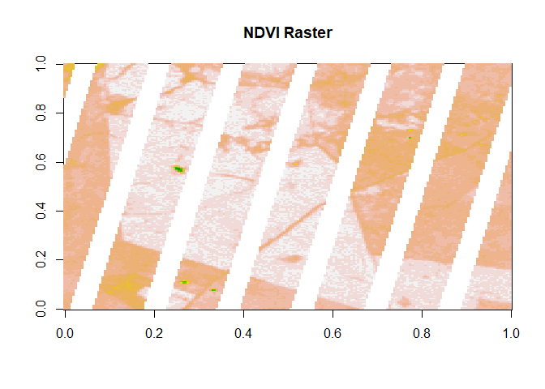

```r
DIM_RASTER <- 200

# Read the .rds file
NDVI <- readRDS(ndvi_files[3])

# Rearrange the list into a matrix
ndvi_matrix <- matrix(unlist(NDVI), nrow = DIM_RASTER, ncol = DIM_RASTER, byrow = TRUE)
na_count_in_each_row <- apply(ndvi_matrix, 1, function(col) sum(is.na(col)))

#cat("\nNA values in each row:\n")
#print(na_count_in_each_row)

image(ndvi_matrix, main = "NDVI Raster", col = terrain.colors(20))
```

* What does this plot inform you of? Shows the vegetation as per the NVDI index. There is NA data in the RDS that is shown as white spaces in the data similar to lines in the data.

##### Preprocessing

NDVI rasters present some anomalies, that we first need to fix.